# Winter 2024 Final Project 141A

Emily Callahan 919436752

2024-02-28

# 1 Abstract

In this course project, my objective is to develop a predictive model capable of accurately forecasting a specific outcome for each trial based on the analysis of neural activity and stimuli data. I will begin by thoroughly examining the datasets, detailing the shifts in neural activity observed in mice across sessions and trials. To aggregate data across trials effectively, I will propose a methodology that involves analyzing sessions and extracting discernible patterns and variances. This process will employ techniques like Principal Component Analysis (PCA) and clustering to unveil meaningful insights. By leveraging these methodologies, I aim to pinpoint significant features contributing to outcome prediction. Subsequently, I will utilize machine learning algorithms such as logistic regression and Support Vector Machines (SVM) to construct and evaluate the predictive model, assessing its accuracy and misclassification error rate. Finally, I will validate the model’s performance on test datasets. Through this endeavor, I intend to produce a robust predictive model capable of accurately forecasting trial outcomes based on neural activity and stimuli data.

# 2 Introduction

I will examine a subset of data obtained from Steinmetz et al. (2019) to delve into the neural activity and decision-making of mice. The study involved experiments conducted on four mice across 18 sessions (originally, the dataset comprised 10 mice and 39 sessions). Each session encompassed numerous trials where mice were presented with visual stimuli on both sides randomly. These stimuli varied in contrast levels, and mice responded to them using a controlled wheel, with subsequent rewards or penalties based on their decisions. Throughout the experiments, neuronal activity in the mice’s visual cortex was recorded in the form of spike trains, representing timestamps of each neuron’s firing. Each trial is associated with several variables, including the type of reward or penalty, contrast levels of stimuli, time bins for spike activity, the spike count of neurons, and the brain region where each neuron is situated.

Studying the neural activity and decision-making processes in mice offers insights that can be extrapolated to human behavior and decision-making in response to specific stimuli. Human decision-making involves processing sensory information and executing actions often motivated by a reward system. While multiple brain regions are involved, the correlation between neuronal activity and decision-making isn’t always straightforward. Neurons associated with decision-related signals may exhibit firing patterns indicative of chosen actions before the action is actually performed. This mouse experiment enables the formulation of hypotheses and inferences regarding human behavior, particularly regarding stimuli’s influence on actions in engaged or disengaged states. It’s important to acknowledge individual differences, leading to varying levels of behavioral engagement and responses to sensory stimuli within tasks.

By leveraging insights from mouse decision-making experiments, we can advance our understanding of the neural mechanisms underlying human behavior and its impact on daily actions.

## 2.1 Background

I will outline details regarding the variables present in this dataset, along with the experimental setup and data acquisition procedure. As mentioned earlier, my focus lies on a subset of data collected by Steinmetz et al. (2019) from four mice across 18 sessions. In each session, mice encountered visual stimuli with varying levels of contrast, providing a spectrum of sensory input for processing. Subsequently, the mice made decisions based on these stimuli, leading to either a reward or penalty as an outcome. The neural activity of the mice was captured in the form of spike trains, facilitating the analysis of their decision-making processes. This experiment serves to elucidate how sensory stimuli influence decision-making in both animals and humans. Previous studies have indicated that specific neurons in the brain exhibit signals related to choice before the action is executed. By scrutinizing neural activity during the trials, this experiment aims to uncover correlations between neurons and their firing patterns, shedding light on the decision-making processes of mice.

```r
setwd("/Users/emilycallahan/Downloads/sessions")
session=list()
for(i in 1:18)
  session[[i]]=readRDS(paste('session',i,'.rds',sep=''))
```

| mouse_name | date_exp | n_brain_area | n_neurons | n_trials | success_rate |
| --- | --- | --- | --- | --- | --- |
| Cori | 2016-12-14 | 8 | 734 | 114 | 0.61 |
| Cori | 2016-12-17 | 5 | 1070 | 251 | 0.63 |
| Cori | 2016-12-18 | 11 | 619 | 228 | 0.66 |
| Forssmann | 2017-11-01 | 11 | 1769 | 249 | 0.67 |
| Forssmann | 2017-11-02 | 10 | 1077 | 254 | 0.66 |
| Forssmann | 2017-11-04 | 5 | 1169 | 290 | 0.74 |
| Forssmann | 2017-11-05 | 8 | 584 | 252 | 0.67 |
| Hench | 2017-06-15 | 15 | 1157 | 250 | 0.64 |
| Hench | 2017-06-16 | 12 | 788 | 372 | 0.69 |
| Hench | 2017-06-17 | 13 | 1172 | 447 | 0.62 |
| Hench | 2017-06-18 | 6 | 857 | 342 | 0.80 |
| Lederberg | 2017-12-05 | 12 | 698 | 340 | 0.74 |
| Lederberg | 2017-12-06 | 15 | 983 | 300 | 0.80 |
| Lederberg | 2017-12-07 | 10 | 756 | 268 | 0.69 |
| Lederberg | 2017-12-08 | 8 | 743 | 404 | 0.76 |
| Lederberg | 2017-12-09 | 6 | 474 | 280 | 0.72 |
| Lederberg | 2017-12-10 | 6 | 565 | 224 | 0.83 |
| Lederberg | 2017-12-11 | 10 | 1090 | 216 | 0.81 |

**Table 1**. Data Summary Across All Sessions

Table 1 provides an overview of session counts and mouse names, along with the experiment dates, trial numbers, neuron counts, brain area numbers, and success rates for each session and mouse. This serves as a concise summary for each session and mouse. It’s worth noting that sessions vary in terms of neuron and trial counts (dimensions), prompting a focused analysis on specific sessions or variables, particularly `spks`, instead of amalgamating all information into one dataframe.

Of particular interest are sessions 1, exhibiting the lowest success rate, and session 17, with the highest success rate. Despite potential behavioral differences between the mice in these sessions, I plan to select a random trial from each to examine the results. I aim to discern the variable contributing to the 20% fluctuation in success rate from lowest to highest. This variance could stem from trial or neuron counts, or perhaps it’s influenced by differences between mice.

#### 2.1.0.1 Each sessions displays the following variables.

```r
names(session[[1]])
```

```
## [1] "contrast_left"  "contrast_right" "feedback_type"  "mouse_name"
## [5] "brain_area"     "date_exp"       "spks"           "time"
```

The variable `contrast_left` denotes the contrast level of visual stimuli presented to the left side of the mice, indicating the strength of the stimuli. Similarly, `contrast_right` represents the contrast level of stimuli presented to the right side. `feedback_type` signifies the feedback type given to mice based on their decisions, determining whether they receive a reward or penalty, with values ranging from 1 for success to -1 for failure. `mouse_name` provides the name of each individual mouse in the dataset. `brain_area` specifies the brain region where neural activity was recorded. `date_exp` records the date of each session. `spks` captures neural activity in spike trains, representing the number of neuron spikes in defined time bins. Finally, `time` indicates the center points of time bins for recorded neural activity.

Number of Trials Accross Sessions - the bar plot shows the number of trials in each session. Differences in the number of trials across sessions indicate heterogeneity in experiemental conditions.

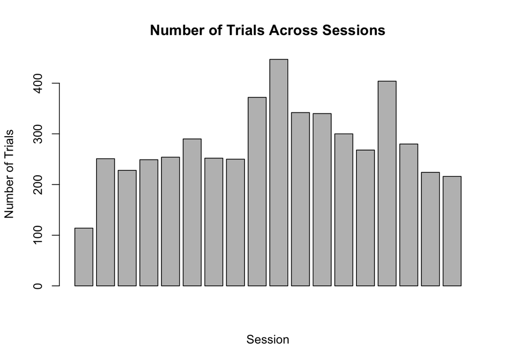

**Figure 1**. Number of Trials Across Sessions

Brain Area Distribution - the bar plot below illustrates the frequency distribution of brain areas across mice. Displaying how specific brain areas are more dominate in the records of the experiment and that certain brain areas are hardly used. This displays heterogeneity.

```
## Sessions per mouse:
```

```
##      Cori Forssmann     Hench Lederberg
##         3         4         4         7
```

```
## Brain Area Distribution:
```

```
##
##   ACA   ACB   AUD   BLA   CA1   CA3    CP    DG   EPd   GPe   ILA    LD   LGd
##   540   155   246   132   799   360   492   416    52   205   144   174   584
##    LH    LP    LS   LSc   LSr    MB    MD   MEA    MG   MOp   MOs   MRN    MS
##    18   124   139    72   475   460   126    41   137   447   585   236    23
##    NB   OLF   ORB  ORBm    OT   PAG   PIR    PL    PO   POL  POST    PT    RN
##    43   181   202   122    26    14    67   448   255   154   295    45    58
##  root   RSP    RT   SCm   SCs  SCsg    SI   SNr   SPF   SSp   SSs   SUB    TH
##  2303    85    44   116    69    19    48   130    15    74   120   423   890
##    TT  VISa VISam  VISl  VISp VISpm VISrl   VPL   VPM    ZI
##   137   243   265   434   592   302   136   301   222   245
```

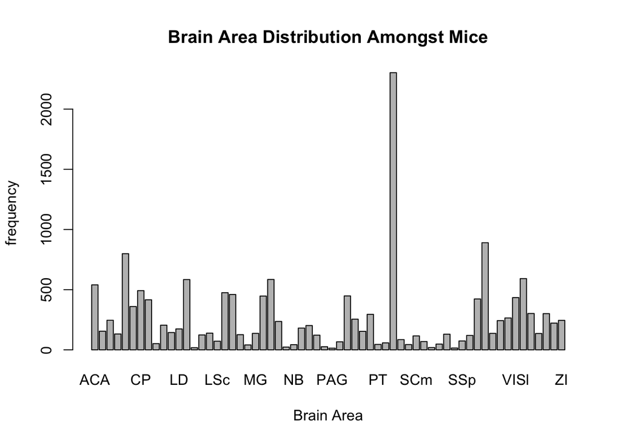

**Figure 2**. Brain Area Distribution Amongst Mice

```
## [1] "ACA"  "MOs"  "LS"   "root" "VISp" "CA3"  "SUB"  "DG"
```

```
## [1] 114
```

```
## [1] 734
```

Extracting some information about session 1 to get me started. The 734 neurons in Session 1 are located in ACA, MOs, LS, root, VISp, CA3, SUB, and DG of the mouse brain. The success rate of the mice is around 0.61. I can visualize the activities of the 8 brain areas across the 114 trials.

```
##       ACA       CA3        DG        LS       MOs      root       SUB      VISp
## 0.5504587 2.7500000 3.2058824 0.8489209 0.8407080 1.0000000 3.3200000 1.7865169
```

| ACA | CA3 | DG | LS | MOs | root | SUB | VISp | Feedback | Left Contrast | Right Contrast | Trial Number |
| --- | --- | --- | --- | --- | --- | --- | --- | --- | --- | --- | --- |
| 1.2660550 | 1.529412 | 2.323529 | 1.9352518 | 0.9380531 | 0.5000000 | 2.080000 | 1.685393 | 1 | 0.0 | 0.5 | 1 |
| 0.5871560 | 1.705882 | 1.558824 | 1.3669065 | 0.7787611 | 0.6666667 | 1.946667 | 1.651685 | 1 | 0.0 | 0.0 | 2 |
| 1.1926606 | 1.985294 | 3.411765 | 1.7266187 | 0.9203540 | 1.4444444 | 2.640000 | 2.275281 | -1 | 0.5 | 1.0 | 3 |
| 0.5137615 | 2.191176 | 2.205882 | 1.0575540 | 0.7079646 | 1.0555556 | 2.800000 | 1.561798 | -1 | 0.0 | 0.0 | 4 |
| 0.7706422 | 1.808824 | 2.058824 | 1.3021583 | 0.7876106 | 0.7777778 | 2.613333 | 1.623596 | -1 | 0.0 | 0.0 | 5 |
| 0.4587156 | 1.852941 | 1.058824 | 0.9064748 | 0.7345133 | 0.6111111 | 1.906667 | 1.280899 | 1 | 0.0 | 0.0 | 6 |

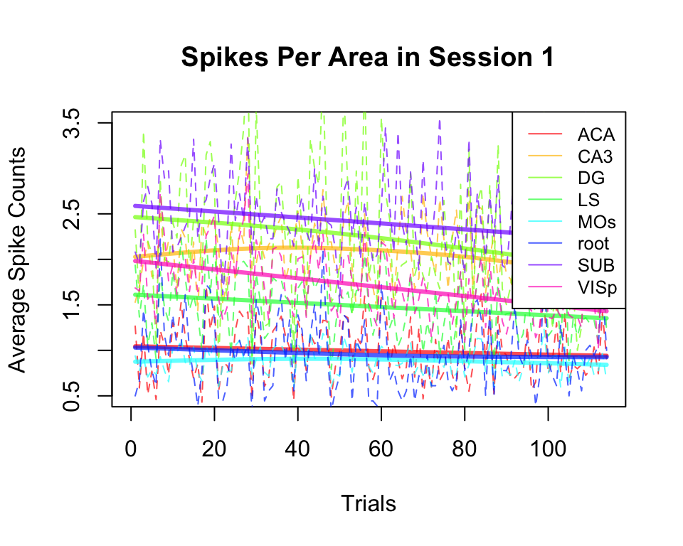

**Figure 3**. Spikes Per Brain Area in Session 1

In Figure 3, the brain areas with the lowest average spike counts are ACA, root, and MOs, while brain area SUB consistently exhibits the highest average spike count across all trials, aligning with the findings from the average spike area function mentioned earlier. Additionally, it’s evident that as trial numbers increase, average spike counts generally decrease. This trend raises questions about potential factors influencing the observed pattern. One possibility is that mice may become fatigued over successive trials, leading to decreased activity and reduced responsiveness to incentives. Alternatively, individual differences among mice could contribute to varying levels of activity, with some being more susceptible to external influences than others.

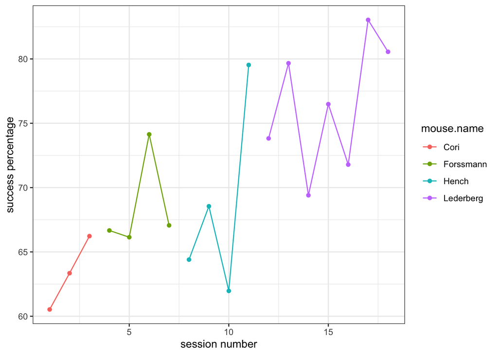

**Figure 4**. Success Rate by Session

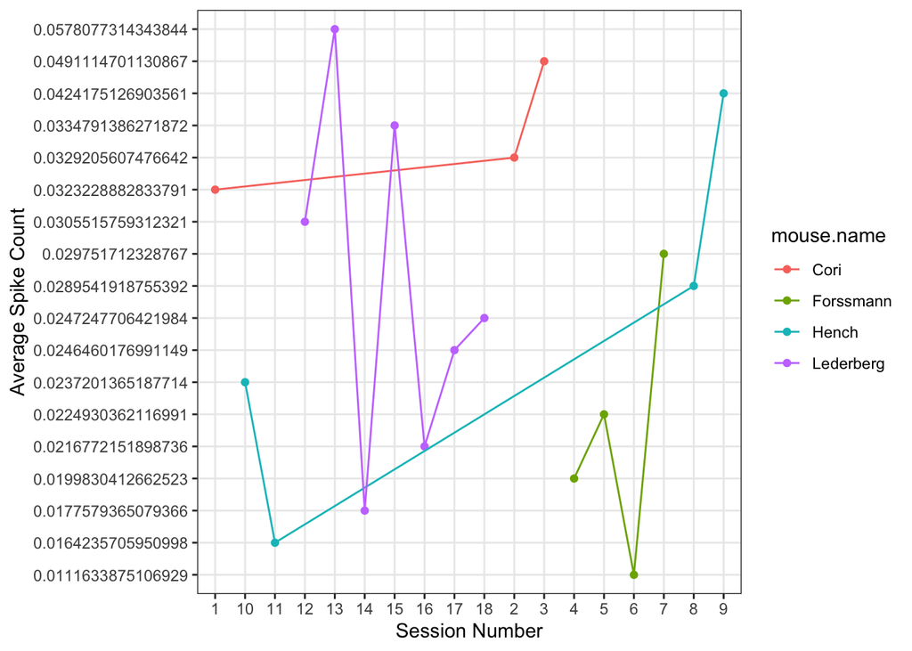

**Figure 5**. Average Spike Count by Session

From these graphs we can visulize that session 17 has the highest success rate amongst sessions and that session 1 has the lowest Success Rate.

Now that I visualized the average spikes per brain area in session 1 with the lowest success rate, I will compare it to the average spikes per brain area in session 17 with the highest success rate and compare my findings.

Session 17

```
## [1] "root" "VPL"  "VPM"  "RT"   "MEA"  "LD"
```

```
## [1] 224
```

```
## [1] 565
```

Extracting information about session 17 to get me started. The 565 neurons in Session 17 are located in root, VPL, VPM, RT, MEA, and LD of the mouse brain. The success rate of the mice is around 0.83. I can visualize the activities of the 6 brain areas across the 224 trials.

```
##       LD      MEA     root       RT      VPL      VPM
## 1.583333 1.048780 1.100559 1.409091 1.540000 1.350000
```

| LD | MEA | root | RT | VPL | VPM | Feedback | Left Contrast | Right Contrast | Trial Number |
| --- | --- | --- | --- | --- | --- | --- | --- | --- | --- |
| 4.166667 | 0.9024390 | 1.0726257 | 1.750000 | 1.66 | 1.1000000 | -1 | 0.0 | 0 | 1 |
| 3.416667 | 0.7317073 | 1.0111732 | 1.159091 | 1.66 | 0.9833333 | 1 | 0.0 | 0 | 2 |
| 1.666667 | 1.4634146 | 1.2094972 | 1.681818 | 1.90 | 1.1000000 | 1 | 0.5 | 1 | 3 |
| 2.833333 | 1.0243902 | 0.8296089 | 1.204545 | 1.76 | 0.9166667 | -1 | 0.0 | 0 | 4 |
| 3.166667 | 0.5365854 | 1.0502793 | 1.386364 | 2.08 | 1.0000000 | 1 | 0.0 | 0 | 5 |
| 2.666667 | 0.9512195 | 1.1871508 | 1.704545 | 2.60 | 1.5000000 | 1 | 0.0 | 1 | 6 |

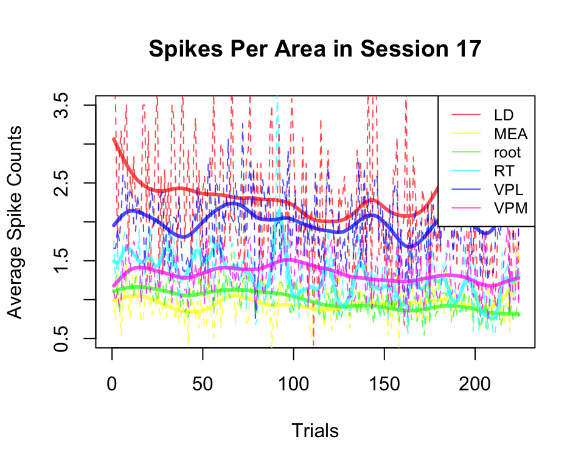

**Figure 6**. Spikes Per Brain Area in Session 17

Figure 6 illustrates significant variability in the average spike counts for brain areas LD, VPL, and RT. This graph differs markedly from the spike per area graph for session 1, as no discernible pattern emerges, and the brain areas with the lowest average spike counts vary from trial to trial. Consequently, I cannot confirm earlier predictions regarding consistency. While brain area LD consistently displays the highest average spike count, identifying the brain area with the lowest count proves challenging. Additionally, there is no clear trend indicating a decrease in average spike counts as trial numbers increase, except for brain area root, which follows this pattern. Unlike in session 1, where fatigue may have influenced mice behavior, this conclusion is not evident here.

To further analyze spikes, I will plot density plots of spikes per time.

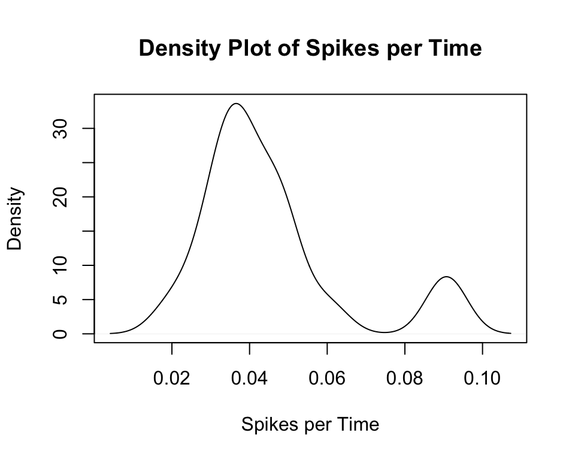

**Figure 7**. Density Plot of Spikes Per Time for All Mice

Now I will demonstrate a sampling distribution using the bootstrap method with my spikes per time values.

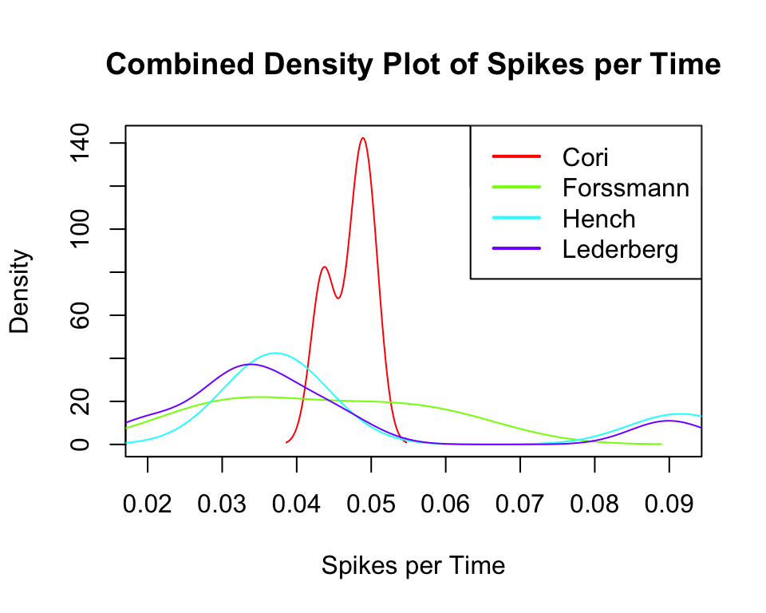

**Figure 8**. Combined Density Plot of Spikes Per Time for Each Mouse

```
## [1] "Spikes Per Time with Highest Density: 0.0488840840612817"
```

…

```
##        V1
##  Min.   :0.02630
##  1st Qu.:0.03589
##  Median :0.04102
##  Mean   :0.04171
##  3rd Qu.:0.04631
##  Max.   :0.06903
```

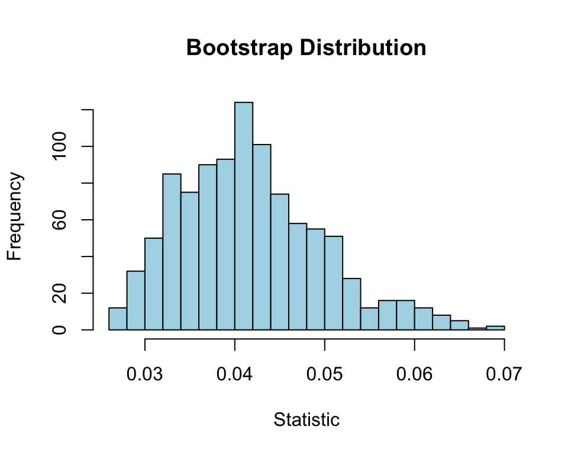

```
## 95% Confidence Intervals:
```

```
##
## Lower: 0.02930745
```

```
##
## Upper: 0.06023051
```

**Figure 9**. Bootstrap Distribution of Spikes per Time Mean Values

This bootstrap visualization is essential as it allows us to approximate the true population using observed samples when the true population is unknown. By drawing samples with replacement and equal probability, the bootstrap procedure estimates the sampling distribution. Consistent with previous visualizations, this display exhibits similar characteristics in terms of shape, range, and mean value.

# 3 Data Integration

```
## [1] 447  40
```

|  | V1 | V2 | V3 | V4 | V5 | V6 | V7 | V8 | V9 | V10 | V11 | V12 | V13 | V14 | V15 | V16 | V17 | V18 | V19 | V20 | V21 | V22 | V23 | V24 | V25 | V26 | V27 | V28 | V29 | … |
| --- | --- | --- | --- | --- | --- | --- | --- | --- | --- | --- | --- | --- | --- | --- | --- | --- | --- | --- | --- | --- | --- | --- | --- | --- | --- | --- | --- | --- | --- | --- |
| 1 | 0.5789474 | 0.2392857 | 0.2166667 | 0.1610738 | 0.2658730 | 0.2730924 | 0.6578947 | 0.2250000 | 0.2733333 | 0.2192394 | 0.4047619 | 0.40562249 | 0.9385965 | 0.2892857 | 0.2500000 | 0.14765101 | 0.3015873 | 0.3012048 | 0.6052632 | 0.2464286 | 0.2400000 | 0.1923937 | 0.3214286 | 0.2449799 | 0.6052632 | 0.2642857 | 0.2300000 | 0.1364653 | 0.2817460 | … |
| 2 | 0.4342629 | 0.5044643 | 0.2947761 | 0.2953216 | 0.3080000 | 0.3582677 | 0.3745020 | 0.5223214 | 0.5186567 | 0.4064327 | 0.5240000 | 0.48818898 | 0.4143426 | 0.3973214 | 0.4365672 | 0.35087719 | 0.5080000 | 0.4212598 | 0.3585657 | 0.5089286 | 0.4738806 | 0.3245614 | 0.4640000 | 0.4370079 | 0.4621514 | 0.6294643 | 0.4626866 | 0.3888889 | 0.5280000 | … |
| 3 | 0.4429825 | 0.4629630 | 0.1980198 | 0.2441176 | 0.2688172 | 0.3344828 | 0.3903509 | 0.3657407 | 0.2500000 | 0.2647059 | 0.2795699 | 0.36206897 | 0.4298246 | 0.5277778 | 0.2871287 | 0.38823529 | 0.3225806 | 0.4586207 | 0.5307018 | 0.5324074 | 0.2698020 | 0.3676471 | 0.3736559 | 0.4206897 | 0.5131579 | 0.4722222 | 0.3316832 | 0.4147059 | 0.3360215 | … |
| 4 | 0.2449799 | 0.4649123 | 0.1642857 | 0.1833333 | 0.0917226 | 0.1904762 | 0.2650602 | 0.6052632 | 0.3785714 | 0.3433333 | 0.2393736 | 0.37698413 | 0.2570281 | 0.5263158 | 0.2500000 | 0.22333333 | 0.1700224 | 0.2976190 | 0.3333333 | 0.6140351 | 0.2785714 | 0.2900000 | 0.1968680 | 0.3214286 | 0.2771084 | 0.6403509 | 0.3071429 | 0.2400000 | 0.2214765 | … |
| 5 | 0.2677165 | 0.2948207 | 0.2544643 | 0.2201493 | 0.1695906 | 0.2840000 | 0.3070866 | 0.2709163 | 0.2812500 | 0.2462687 | 0.2163743 | 0.22000000 | 0.2755906 | 0.2988048 | 0.2678571 | 0.26865672 | 0.2309942 | 0.2920000 | 0.2992126 | 0.2988048 | 0.3214286 | 0.2649254 | 0.2076023 | 0.3680000 | 0.3661417 | 0.3346614 | 0.4285714 | 0.3731343 | 0.2719298 | … |
| 6 | 0.1517241 | 0.1885965 | 0.2407407 | 0.1188119 | 0.1558824 | 0.1102151 | 0.1344828 | 0.1140351 | 0.2314815 | 0.1163366 | 0.1264706 | 0.09139785 | 0.1482759 | 0.1798246 | 0.1435185 | 0.05940594 | 0.1088235 | 0.1102151 | 0.1551724 | 0.2017544 | 0.1805556 | 0.1014851 | 0.1323529 | 0.1209677 | 0.1862069 | 0.1842105 | 0.2083333 | 0.1212871 | 0.1588235 | … |

These are the initial six rows of the dataframe showcasing average spike matrices across all sessions. To accommodate the varying dimensions across sessions, I initially identified the maximum number of trials across all sessions. Then, I iterated through all trials and sessions, padding the spike matrix with zeros if they did not match the maximum trial count. Finally, I computed the average spike matrix for each session, resulting in a 447x40 matrix. The presented dataframe displays the first six rows. I will utilize this dataframe for further analysis, including PCA and clustering. …

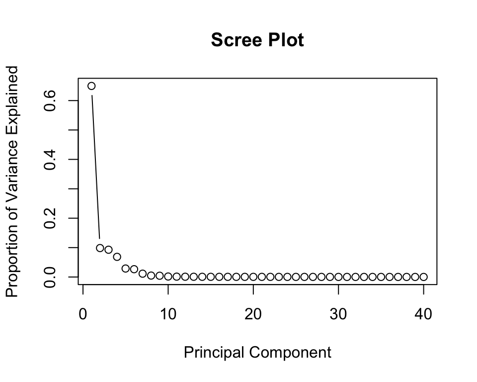

**Figure 10**. Scree Plot of Principal Components vs Proportion of Variance Explained

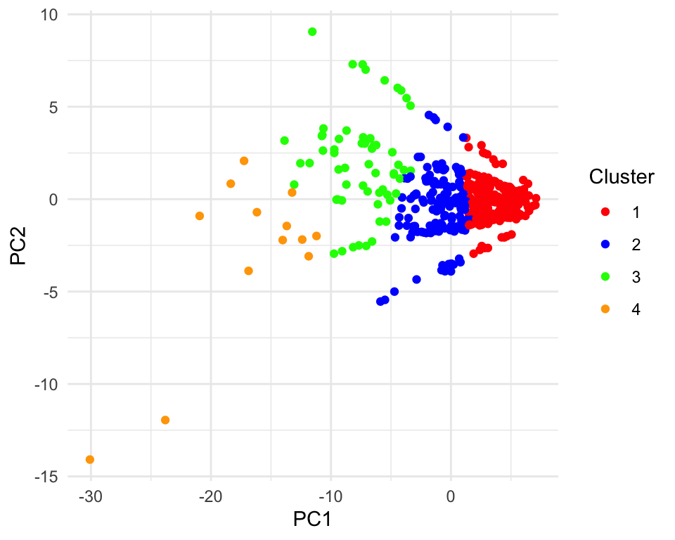

**Figure 11**. Scatter Plot from K-Means Clustering

Figure 11 displays a scatterplot generated from the k-means clustering method. I adjusted the number of clusters to align with the first four principal components previously identified as significant. Upon observation, the first two clusters appear close to each other yet well-separated, indicating effective clustering performance. However, the third cluster appears less tightly clustered and more dispersed, while the fourth cluster exhibits significant spread, suggesting greater variability within. Additionally, clusters 1 and 2 contain substantially more data points compared to the other clusters. Notably, cluster 4 includes two outliers that are part of the cluster but are distinctly separated from the rest of the data points. In summary, k-means clustering proves to be a reliable method as the clusters are distinct, easily discernible, well-separated, and largely tightly clustered. …

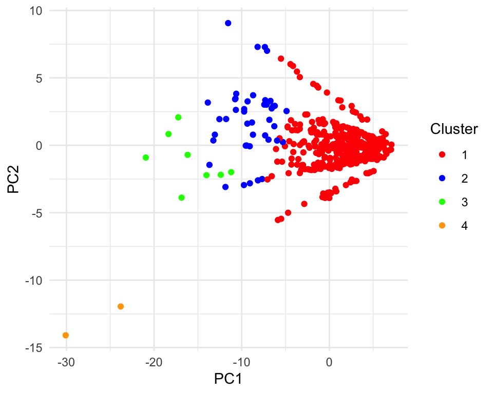

**Figure 12**. Scatter Plot from Hierarchical Clustering

Figure 12 depicts the scatterplot generated by the hierarchical clustering method, with the number of clusters adjusted to correspond with the first four principal components identified earlier. Notably, the first cluster appears tightly clustered, indicating strong intra-cluster similarity. However, clusters 2 and 3 exhibit greater spread, suggesting increased variability within these clusters. Cluster 3 notably contains fewer data points compared to clusters 1 and 2. Moreover, cluster 4 comprises only two data points, each separate from the other, leading to the conclusion that this entire cluster may be an outlier.

While some overlap between clusters is apparent, it is insufficient to imply similarity or ambiguity between data points. In summary, hierarchical clustering proves to be a viable method as the clusters are mostly distinct and easily discernible, although k-means clustering emerges as a stronger approach. …

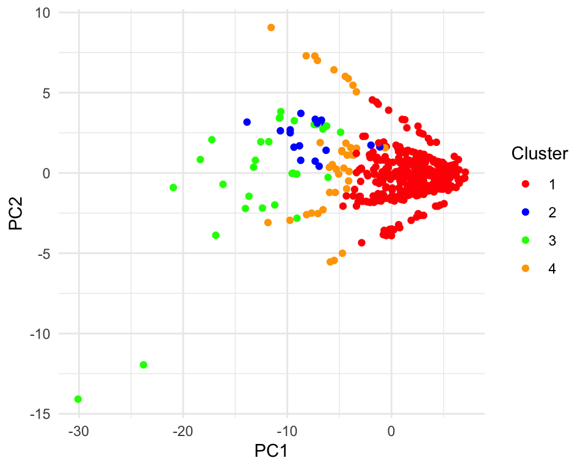

**Figure 13**. Scatter Plot from Spectral Clustering

Figure 13 presents the scatterplot generated by the spectral clustering method, with the number of clusters adjusted to align with the first four principal components previously identified as significant. Notably, the first cluster appears relatively tightly clustered, suggesting strong intra-cluster similarity and containing the most data points. However, the remaining clusters exhibit significant spread and overlap, indicating poor clustering performance and greater variability within. Additionally, one cluster, adjacent to another, contains two outliers significantly distant from all other clusters. These three clusters possess significantly fewer data points than the first cluster and lack distinctiveness or ease of differentiation. In summary, spectral clustering proves unsuitable for this average spike matrix data, as the clusters are neither tightly clustered nor distinct. …

# 4 Model Training and Prediction

I’m partitioning the average spike matrix across all sessions data into training and testing sets, adhering to an 80% and 20% split. Taking into consideration the four important principal components, I’m evaluating various predictive models on the training and testing datasets to identify the one with the highest accuracy score. This selected model will then be applied to the actual testing data provided. …

```
## [1] "Logistic Regression Classifier"
```

```
## [1] "Accuracy: 0.640449438202247"
```

```
## [1] "Misclassification Error Rate: 0.359550561797753"
```

I utilized the logistic regression classifier for training based on the provided training and testing data. By aggregating the predictions on the test data and dividing by the length of the test labels, I computed an accuracy score of approximately 64% and a misclassification error rate of roughly 36%. This implies that the model accurately predicts 64% of the instances within the dataset. While I aimed for a higher accuracy score considering the dataset’s size, surpassing the 50% mark suggests that this is a reasonably effective model. …

```
## [1] "SVM Classifier"
```

```
## [1] "Accuracy: 0.640449438202247"
```

```
## [1] "Misclassification Error Rate: 0.359550561797753"
```

```
## [1] "Confusion Matrix:"
```

```
##             test_labels
## predictions4 -1  1
##           -1  0  0
##           1  32 57
```

```
## [1] "Precision: 0.640449438202247"
```

```
## [1] "F1 Score: 0.780821917808219"
```

I utilized the support vector machines (SVM) classifier to train on the provided training and testing data. By summing up predictions on the test data and dividing by the length of the test labels, I determined an accuracy score of roughly 64% and a misclassification error rate of approximately 36%, demonstrating the model’s ability to correctly predict 64% of instances within the dataset. While I aimed for a higher accuracy score considering the dataset’s size, surpassing the 50% mark suggests a reasonably effective model. The confusion matrix illustrates true positives, true negatives, false positives, and false negatives, offering insights into prediction performance against actual class labels. With a precision score of 64%, indicating the proportion of correctly predicted true positive instances, and an f1-score of 78%, which combines precision and recall while considering false positives and false negatives, the SVM classifier emerges as a strong contender for my final prediction model. …

```
## [1] "Decision Tree Classifier"
```

```
## [1] "Accuracy: 0.640449438202247"
```

```
## [1] "Misclassification Error Rate: 0.359550561797753"
```

```
## [1] "Confusion Matrix:"
```

```
##             test_label
## predictions1 -1  1
##           -1  0  0
##           1  32 57
```

```
## [1] "Precision: 0.640449438202247"
```

```
## [1] "F1 Score: 0.780821917808219"
```

I would like the accuracy score to be higher, but since it is above 50%, I would say that this is a decent model. The confusion matrix shows the true positives, true negatives, false positives, and false negatives of the predictions compared to the actual class labels. …

```
## [1] "K-Nearest Neighbors Classifier"
```

```
## [1] "Accuracy: 0.449438202247191"
```

```
## [1] "Misclassification Error Rate: 0.550561797752809"
```

```
## [1] "Confusion Matrix:"
```

```
##       test_labels
## model5 -1  1
##     -1  7 24
##     1  25 33
```

```
## [1] "Precision: 0.568965517241379"
```

```
## [1] "F1 Score: 0.573913043478261"
```

I conducted training of the k-nearest neighbors (KNN) classifier using the provided training and testing data. By aggregating predictions on the test data and dividing by the length of the test labels, I computed an accuracy score of approximately 45% and a misclassification error rate of around 55%. This indicates that the model accurately predicts 45% of instances within the dataset. Given that the accuracy score falls below 50%, I consider this model unsatisfactory. Therefore, I will not be utilizing it as my final prediction model. …

```
## [1] "Random Forest Classifier"
```

```
## [1] "Accuracy: 0.528089887640449"
```

```
## [1] "Misclassification Error Rate: 0.471910112359551"
```

```
## [1] "Confusion Matrix:"
```

```
##             test_label
## predictions3 -1  1
##           -1  3 13
##           1  29 44
```

```
## [1] "Precision: 0.602739726027397"
```

```
## [1] "F1 Score: 0.676923076923077"
```

# 5 Results/Prediction Performance

I will now discuss the performance of my SVM prediction model based on the given test data.

```
## [1] "Confusion Matrix:"
```

```
##                test_labels
## predictionstest -1  1
##              -1  0  0
##              1  28 72
```

```
## [1] "Accuracy Score: 0.72"
```

```
## [1] "Misclassification Rate: 0.28"
```

```
## [1] "Precision: 0.72"
```

```
## [1] "F1 Score: 0.837209302325581"
```

After obtaining the average spike matrix across all sessions for the test data, I conducted PCA on the matrix and identified the first four principal components as the most significant, explaining a substantial proportion of variance in the dataset. Subsequently, I collected feedback types from all sessions and organized them into a variable, appending these feedback types to another vector. This enabled me to evaluate the accuracy of my SVM prediction model.I retained my original training data and replaced the simulated test data with the actual test data. By aggregating predictions on the test data and dividing by the length of the test labels, I computed an accuracy score of 72% and a misclassification error rate of 28%, indicating that the model correctly predicts 72% of instances within the dataset. This outcome is highly favorable. The confusion matrix provided insights into true positives, true negatives, false positives, and false negatives in comparison to actual class labels. With a precision score of 72%, signifying the proportion of correctly predicted true positive instances, and an f1-score of 84%, which integrates precision and recall while considering false positives and false negatives, the SVM classifier demonstrated strong performance as a prediction model for the test data, as corroborated by the results.

# 6 Conclusion/Discussion

In conclusion, my project involved scrutinizing session discrepancies among mice and their corresponding success rates. This entailed delving into spikes per brain area across sessions and analyzing feedback types. Subsequently, I delved deeper into dataset visualization through density plots and a bootstrap distribution.

My focus shifted to PCA and clustering using the average spikes matrix spanning all trials and sessions. I visualized essential principal components via a scree plot, facilitating the interpretation of variance proportion in the dataset and guiding clustering decisions across various methodologies.

Subsequently, I partitioned my dataset into 80% training data and 20% testing data, considering selected principal components. I rigorously tested multiple models to ascertain the highest accuracy scores, lowest misclassification error rates, and optimal precision and f1 scores. The culmination involved evaluating my final prediction model against provided test data, yielding commendable performance.

The primary objective of this endeavor was crafting a predictive model to anticipate trial outcomes using neural activity data and stimuli. This aim was successfully achieved, holding significant practical implications for real-world applications, including forecasting human behavioral responses to stimuli.

While navigating this expansive dataset posed challenges, particularly in identifying pertinent variables, clarity emerged as I refined my outcome objectives and applied appropriate visualization techniques.

Moving forward, I envision exploring alternative classifiers to attain even higher accuracy and precision levels. This could involve experimentation with different variables, PCA configurations, and clustering methods. Nonetheless, the SVM classifier proved notably effective for my test data, underscoring its utility in predictive modeling.

# 7 References

Steinmetz, N.A., Zatka-Haas, P., Carandini, M. et al. Distributed coding of choice, action and engagement across the mouse brain. Nature 576, 266–273 (2019). https://doi.org/10.1038/s41586-019-1787-x

Utilized Chatgpt to check code, ask questions about test data, and questions about errors along the way. https://chat.openai.com/share/e2d002e6-53cf-484d-aedf-625c9baa83b9

# 9 Appendix

```r
knitr::opts_chunk$set(fig.pos = 'H')
library(tidyverse)
library(magrittr)
library(knitr)
library(dplyr)
library(ggplot2)
library(htmlwidgets)
library(tidyr)
library(xgboost)
library(boot)
library(tibble)
library(kernlab)
library(caret)
library(e1071)
library(randomForest)
library(class)
library(meta)
setwd("/Users/emilycallahan/Downloads/sessions")
session=list()
for(i in 1:18)
  session[[i]]=readRDS(paste('session',i,'.rds',sep=''))
#determine the number of sessions in the 'session' list
n.session=length(session)

#create a tibble called 'meta' to store the summar statistics
meta <- tibble(
  #Initialize 'mouse_name' column with 'name
  mouse_name = rep('name',n.session),
  #Initialize 'date_exp' column with 'dt'
  date_exp =rep('dt',n.session),
  #Initialize 'n_brain_area' column with zeros
  n_brain_area = rep(0,n.session),
  #Initialize 'n_neurons' column with zeros
  n_neurons = rep(0,n.session),
  #Initialize 'n_trials' column with zeros
  n_trials = rep(0,n.session),
  #Initialize 'success_rate' column with zeros
  success_rate = rep(0,n.session)
)


#Iterate over each session to calculate summary statistics
#access the i-th session
for(i in 1:n.session){
  tmp = session[[i]];
#extract relevant information from the current sessions and update the corresponding columns in 'meta'
#Store mouse name in the 'mouse_name' column
  meta[i,1]=tmp$mouse_name;
  #Store date of experiment in the date_exp column
  meta[i,2]=tmp$date_exp;
  #Calculate the number of unique brain areas and store in the 'n_brain_area' column
  meta[i,3]=length(unique(tmp$brain_area));
  #Determine the number of neurons and store in the n_neurons' column
  meta[i,4]=dim(tmp$spks[[1]])[1];
  #calculate the number of trials and store in the n_trials column
  meta[i,5]=length(tmp$feedback_type);
  #Calculate the average success rate and store in the 'success_rate' column
  meta[i,6]=mean(tmp$feedback_type+1)/2;
}
#Render the 'meta' tibble as an HTML table
#specify that the output format should be html
#add CSS classes to the table for styling
#specify the number of decimal places to displayin numeric columns

kable(meta, format = "html", table.attr = "class='table table-striped'",digits=2)
names(session[[1]])
#dermine the number of sessions
sessions <- length(session)
#calcuate the number of neurons in each session using the 'sapply' function
neurons <- sapply(session, function(s)length(s$spks))

#calculate the number of trials in each session using the 'sapply' function
num_trials <-sapply(session,function(s) length(s$spks))

#create a bar plot of the number of trials across sessions
barplot(num_trials,
        xlab = "Session",
        ylab = "Number of Trials",
        main = "Number of Trials Across Sessions")
#calculate the number of sessions per mouse using 'sapply', 'unlist', and 'lapply'
sessions_per_mouse <- sapply(unique(unlist(lapply(session,function(s)s$mouse_name))),
                             function(m)sum(unlist(lapply(session, function(s)s$mouse_name==m))))

#calculate the distribution of brain areas across sessions using 'table','unlist',and 'lapply'
brain_area_distribution <- table(unlist(lapply(session,function(s)s$brain_area)))

#print the sessions per mouse
cat("Sessions per mouse:\n")
print(sessions_per_mouse)

#print the brain area distribution
cat("Brain Area Distribution:\n")
print(brain_area_distribution)
#create a bar plot of the brain area distribution using 'barplot'
barplot(brain_area_distribution, xlab= "Brain Area", ylab = "frequency",
        main ="Brain Area Distribution Amongst Mice")
unique(session[[1]]$brain_area) # names of each unique brain area
length(session[[1]]$feedback_type) # number of trials
nrow(session[[1]]$spks[[1]]) # number of neurons
sessionnum = 1
trialNumber = 81 # random trial in the 114 trials

spk.trial = session[[sessionnum]]$spks[[trialNumber]]
area = session[[sessionnum]]$brain_area

# calculate the number of spikes for each neuron during this trial
spk.count=apply(spk.trial,1,sum)

# average spikes across neurons that live in the same area

tmp <- data.frame(
  area = area,
  spikes = spk.count
)
# Calculate the average by group
spk.average.dplyr =tmp %>%
  group_by(area) %>%
  summarize(mean= mean(spikes))
# function of above code to apply to all trials

averagespkarea <- function(trialNumber, sessionnum){
  spktrial = sessionnum$spks[[trialNumber]]
  area = sessionnum$brain_area
  spkCount = apply(spktrial, 1, sum)
  spkAverage = tapply(spkCount, area, mean)
  return(spkAverage)
  }

averagespkarea(81, session[[sessionnum]])
numoftrials = length(session[[sessionnum]]$feedback_type)
numofA = length(unique(session[[sessionnum]]$brain_area ))

# create a data frame that contains the average spike counts for each area, feedback type, two contrasts, and trial number

trialsum = matrix(nrow = numoftrials, ncol= numofA+1+2+1)
for(i in 1:numoftrials){
  trialsum[i,]=c(averagespkarea(i, session[[sessionnum]]),
                          session[[sessionnum]]$feedback_type[i],
                        session[[sessionnum]]$contrast_left[i],
                        session[[sessionnum]]$contrast_right[i],
                        i)
}

colnames(trialsum)=c(names(averagespkarea(i,session[[sessionnum]])), 'Feedback', 'Left Contrast', 'Right Contrast', 'Trial Number')

# turn into data frame
trialsum <- as_tibble(trialsum)
head(trialsum)
areacolor = rainbow(n=numofA, alpha=0.7)

plot(x=1, y=0, col='white',xlim=c(0,numoftrials), ylim=c(0.5,3.5), xlab="Trials",ylab="Average Spike Counts", main=paste("Spikes Per Area in Session", sessionnum))


for(i in 1:numofA){
  lines(y = trialsum[[i]], x = trialsum$`Trial Number`, col = areacolor[i],lty=2,lwd=1)
  lines(smooth.spline(trialsum$`Trial Number`, trialsum[[i]]), col = areacolor[i],lwd=3)
}

legend("topright",
  legend = colnames(trialsum)[1:numofA],
  col = areacolor,
  lty = 1,
  cex = 0.8
)
#Create an empty success matrix with 18 rows and 3 columns
success.matrix <- base::matrix(nrow = 18, ncol = 3)
#Create an empty list to store names
names.list = list()
```

```r
#define a function to calculate success percentage for a given session
success.percent <-function(s) {
  z = sum(session[[s]]$feedback_type == 1)

  percent.success = 100*z/length(session[[s]]$feedback_type)
  return(percent.success)
}

#iterate over sessions and calculate success percentage
for(s in 1:18) {
  success.matrix[s,] = c(s,success.percent(s), session[[s]]$mouse_name)
}
#assign column names to success matrix
colnames(success.matrix)= c("session.number", "success.percent","mouse.name")
#convert success matrix to a tibble
success.table <- as_tibble(success.matrix)%>%
  mutate(success.percent = as.numeric(success.percent))%>%
           mutate(session.number = as.numeric(session.number))

#create a ggplot with success table data
ggplot(success.table,aes(x = session.number, y = success.percent))+
                         geom_point(aes(group= mouse.name,color = mouse.name))+
                           theme_bw()+
                           geom_line(aes(group= mouse.name,color = mouse.name))+
                           ylab("success percentage")+
                           xlab("session number")

#creating an empty matrix with 18 rows and 3 columns
mean.matrix <- base::matrix(nrow = 18 , ncol = 3)
names.list = list()

for(s in 1:18){
  for(t in length(session[[s]]$feedback_type)){
    spks.mean = mean(c(session[[s]]$spks[[t]]))
  }
  mean.matrix[s,] = c(s,spks.mean, session[[s]]$mouse_name)
}
#assign colnames
colnames(mean.matrix) = c("Session Number", "Average Spike Count", "Mouse Name")
#converting the matrix to a tibble for easier data manipulation
mean.table <- as_tibble(mean.matrix)

session.number = mean.table$`Session Number`
mouse.name = mean.table$`Mouse Name`
spks.mean = mean.table$`Average Spike Count`

#creating a scatter plot with lines
ggplot(mean.table, aes(x = session.number, y = spks.mean))+
 geom_point(aes(group= mouse.name,color = mouse.name))+
 theme_bw()+
 geom_line(aes(group= mouse.name,color = mouse.name))+
 ylab("Average Spike Count")+
 xlab("Session Number")
unique(session[[17]]$brain_area) # names of each unique brain area
length(session[[17]]$feedback_type) # number of trials
nrow(session[[17]]$spks[[1]]) # number of neurons
sessionnum = 17
trialNumber = 81 # random trial in the 224 trials

spk.trial = session[[sessionnum]]$spks[[trialNumber]]
area = session[[sessionnum]]$brain_area

# calculate the number of spikes for each neuron during this trial
spk.count=apply(spk.trial,1,sum)

# average spikes across neurons that live in the same area
tmp <- data.frame(
  area = area,
  spikes = spk.count
)
# Calculate the average by group
spk.average.dplyr =tmp %>%
  group_by(area) %>%
  summarize(mean= mean(spikes))
# function of above code to apply to all trials
averagepkarea <- function(trialNumber, sessionnum){
  spktrial = sessionnum$spks[[trialNumber]]
  area = sessionnum$brain_area
  spkCount = apply(spktrial, 1, sum)
  spkAverage = tapply(spkCount, area, mean)
  return(spkAverage)
  }

averagepkarea(81, session[[sessionnum]])
numoftrials = length(session[[sessionnum]]$feedback_type)
numofA = length(unique(session[[sessionnum]]$brain_area ))

#create a data frame that contains the average spike counts for each area, feedback type, two contrasts, and trial number

trialsum = matrix(nrow = numoftrials, ncol= numofA+1+2+1)
for(i in 1:numoftrials){
  trialsum[i,]=c(averagespkarea(i, session[[sessionnum]]),
                          session[[sessionnum]]$feedback_type[i],
                        session[[sessionnum]]$contrast_left[i],
                        session[[sessionnum]]$contrast_right[i],
                        i)
}

colnames(trialsum)=c(names(averagespkarea(i,session[[sessionnum]])), 'Feedback', 'Left Contrast', 'Right Contrast', 'Trial Number')

# turn into data frame
trialsum <- as_tibble(trialsum)
head(trialsum)
areacolor = rainbow(n=numofA, alpha=0.7)

plot(x=1, y=0, col='white',xlim=c(0,numoftrials), ylim=c(0.5,3.5), xlab="Trials",ylab="Average Spike Counts", main=paste("Spikes Per Area in Session", sessionnum))


for(i in 1:numofA){
  lines(y = trialsum[[i]], x = trialsum$`Trial Number`, col = areacolor[i],lty=2,lwd=1)
  lines(smooth.spline(trialsum$`Trial Number`, trialsum[[i]]), col = areacolor[i],lwd=3)
}

legend("topright",
  legend = colnames(trialsum)[1:numofA],
  col = areacolor,
  lty = 1,
  cex = 0.8
)

feedback_list <- list()

for (i in 1:length(session)) {
  feedback_data <- session[[i]]$feedback_type

  # Add the feedback data to the list
  feedback_list[[i]] <- feedback_data
}
mousenames <- c()

# Iterate over each session
for (i in 1:length(session)) {
  mouse <- session[[i]]$mouse_name

  mousenames <- c(mousenames, mouse)
}

uniquemousenames <- unique(mousenames)
spikespertime <- list()

for (i in 1:length(session)) {
  mouse <- session[[i]]$mouse_name
  spikematrix <- session[[i]]$spks
  timeduration <- session[[i]]$time

  spikes <- 0

  # Calculate the sum of spikes per time for each matrix
  for (j in 1:length(spikematrix)) {
    spikes <- spikes + sum(spikematrix[[j]])
  }

  # numeric value of time_duration
  timedurationnumeric <- sapply(timeduration, as.numeric)

  #calculate spikes per time
  spikespertime[[i]] <- spikes / sum(timedurationnumeric)
}

#create a vector of spikes per time values
spikepertimeval <- unlist(spikespertime)

densityplot <- density(spikepertimeval)

plot(densityplot, main = "Density Plot of Spikes per Time", xlab = "Spikes per Time", ylab = "Density")

densityplots <- list()

for (mousename in uniquemousenames) {
  # Subset the spikes per time values for the current mouse name
  spikepertimeval <- unlist(spikespertime[mousenames == mousename])

  # Create a density plot for the current mouse name
  densityplot <- density(spikepertimeval)

  # Store the density plot in the list
  densityplots[[mousename]] <- densityplot
}
# Calculate the maximum density value
maxdensity <- max(sapply(densityplots, function(x) max(x$y)))

#create an empty plot to hold the combined density plots
plot(NA, xlim = range(spikespertime), ylim = c(0, maxdensity),
     main = "Combined Density Plot of Spikes per Time",
     xlab = "Spikes per Time", ylab = "Density")
```

```r
colors <- rainbow(length(densityplots))

for (i in 1:length(densityplots)) {

  mousename <- names(densityplots)[i]
  densityplot <- densityplots[[i]]

  # Add the density plot curve to the combined plot
  lines(densityplot, col = colors[i])

  legend("topright", legend = mousename, col = colors[i], lwd = 2)
}

legend("topright", legend = names(densityplots), col = colors, lwd = 2)

# Find the spikes per time number with the highest density
max_density_val <- -Inf
max_density_spk_time <- NULL

for (i in 1:length(densityplots)) {

  densityplot <- densityplots[[i]]

  # Find the index of the maximum density value
  max_density_index <- which.max(densityplot$y)

  # Get the spikes per time number with the highest density
  spikespertimevalue <- densityplot$x[max_density_index]

  #check if it has higher density than previous maximum
  if (densityplot$y[max_density_index] > max_density_val) {
    max_density_val <- densityplot$y[max_density_index]
    max_density_spk_time <- spikespertimevalue
  }
}

print(paste("Spikes Per Time with Highest Density:", max_density_spk_time))

custom_stat <- function(data, index) {
  mean(data[index])
}

n_iterations <- 1000

# bootstrap resampling
bootstrap_result <- boot(spikepertimeval, statistic = custom_stat, R = n_iterations)

# Get the bootstrap estimates
bootstrap_est <- bootstrap_result$t

summary(bootstrap_est)

hist(bootstrap_est, breaks = 30, col = "lightblue", main = "Bootstrap Distribution", xlab = "Statistic")

confidence_intervals <- quantile(bootstrap_est, probs = c(0.025, 0.975))

cat("95% Confidence Intervals:")
cat("\nLower:", confidence_intervals[1])
cat("\nUpper:", confidence_intervals[2])

# Determine the maximum number of trials across all sessions
max_trials <- max(sapply(session, function(x) length(x$spks)))

# Initialize an empty matrix to store the average spike matrix
average_spike_matrix <- matrix(0, nrow = max_trials, ncol = 40)

# Initialize a counter to keep track of the number of trials in each session
session_trial_counter <- rep(0, length(session))

for (i in 1:length(session)) {
  num_trials <- length(session[[i]]$spks)

  for (j in 1:num_trials) {
    spike_matrix <- session[[i]]$spks[[j]]

    # Check if the spike matrix has more rows than the maximum number of trials
    if (dim(spike_matrix)[1] > max_trials) {
      spike_matrix <- spike_matrix[1:max_trials, ]
    }

    # Pad the spike matrix with zeros to match the maximum number of trials
    padded_spike_matrix <- rbind(spike_matrix, matrix(0, nrow = max_trials - dim(spike_matrix)[1], ncol = 40))

    # Add the spike counts to the average spike matrix
    average_spike_matrix <- average_spike_matrix + padded_spike_matrix

    session_trial_counter[i] <- session_trial_counter[i] + 1
  }
}

# Calculate the average spike matrix for each session
session_average_spike_matrix <- average_spike_matrix / session_trial_counter

# Convert session_average_spike_matrix to a dataframe
session_average_spike_matrix_df <- as.data.frame(session_average_spike_matrix)

print(dim(session_average_spike_matrix_df))
head(session_average_spike_matrix_df)
pca_result <- prcomp(session_average_spike_matrix, scale = TRUE)
# principal components
principal_comp <- pca_result$x

# proportion of variance explained by each component
variance_explained <- pca_result$sdev^2 / sum(pca_result$sdev^2)

# Scree plot
plot(1:length(variance_explained), variance_explained, type = "b",
     xlab = "Principal Component", ylab = "Proportion of Variance Explained", main = "Scree Plot")
num_components <-4
selected_components <- principal_comp[, 1:num_components]
set.seed(126)
k <- 4

# K-means clustering
kmeans_result <- kmeans(selected_components, centers = k)

# Get the cluster assignments for each trial
cluster_labels <- kmeans_result$cluster

# Create a data frame combining the selected principal components and cluster labels
data <- data.frame(PC1 = selected_components[, 1],
                   PC2 = selected_components[, 2],
                   PC3 = selected_components[, 3],
                   PC4 = selected_components[, 4],
                   Cluster = as.factor(cluster_labels))

ggplot(data, aes(x = PC1, y = PC2, color = Cluster)) +
  geom_point() +
  labs(x = "PC1", y = "PC2") +
  scale_color_manual(values = c("red", "blue", "green", "orange")) +
  theme_minimal()

#hierarchical clustering
hclust_result <- hclust(dist(selected_components))

k <- 4
# Cut the dendrogram to obtain cluster assignments
cluster_labels <- cutree(hclust_result, k = k)

# Create a data frame combining the selected principal components and cluster labels
data <- data.frame(PC1 = selected_components[, 1],
                   PC2 = selected_components[, 2],
                   PC3 = selected_components[, 3],
                   PC4 = selected_components[, 4],
                   Cluster = as.factor(cluster_labels))

ggplot(data, aes(x = PC1, y = PC2, color = Cluster)) +
  geom_point() +
  labs(x = "PC1", y = "PC2") +
  scale_color_manual(values = c("red", "blue", "green", "orange")) +
  theme_minimal()
set.seed(123)
# spectral clustering
k <- 4
spectral_result <- specc(selected_components, centers = k)

# Assign cluster labels
cluster_labels <- as.factor(spectral_result)

# Create a data frame combining the selected principal components and cluster labels
data <- data.frame(PC1 = selected_components[, 1],
                   PC2 = selected_components[, 2],
                   PC3 = selected_components[, 3],
                   PC4 = selected_components[, 4],
                   Cluster = cluster_labels)

ggplot(data, aes(x = PC1, y = PC2, color = Cluster)) +
  geom_point() +
  labs(x = "PC1", y = "PC2") +
  scale_color_manual(values = c("red", "blue", "green", "orange")) +
  theme_minimal()
labels <- numeric()

for (session_num in 1:18) {
  session_labels <- session[[session_num]]$feedback_type

  #Append the feedback types to the labels vector
  labels <- c(labels, session_labels)
}

# labels vector must match the length of selected_components
labels <- labels[1:nrow(selected_components)]
labels <- as.factor(labels)
```

```r
# Split the data into training and test sets
set.seed(42)
train_indices <- createDataPartition(labels, p = 0.8, list = FALSE)
train_data <- selected_components[train_indices, ]
train_labels <- labels[train_indices]
test_data <- selected_components[-train_indices, ]
test_labels <- labels[-train_indices]
# Train a logistic regression classifier
model2 <- glm(train_labels ~ ., data = as.data.frame(train_data), family = binomial)

# Make predictions on the test data
predictions2 <- predict(model2, newdata = as.data.frame(test_data), type = "response")

# Convert predicted probabilities to class labels
predictions2 <- ifelse(predictions2 > 0.5, 1, 0)

print("Logistic Regression Classifier")

accuracy2 <- sum(predictions2 == test_labels) / length(test_labels)
print(paste("Accuracy:", accuracy2))

misclassified2 <- sum(predictions2 != test_labels)

error_rate2 <- misclassified2 / length(test_labels)

print(paste("Misclassification Error Rate:", error_rate2))
labels <- as.factor(labels)

# Split the data into training and test sets
set.seed(42)
train_indices <- createDataPartition(labels, p = 0.8, list = FALSE)
train_data <- selected_components[train_indices, ]
train_labels <- labels[train_indices]
test_data <- selected_components[-train_indices, ]
test_labels <- labels[-train_indices]
#train an SVM classifier
model4 <- svm(train_data, train_labels)

# Make predictions on the test data
predictions4 <- predict(model4, test_data)

print("SVM Classifier")

accuracy4 <- sum(predictions4 == test_labels) / length(test_labels)
print(paste("Accuracy:", accuracy4))

misclassified4 <- sum(predictions4 != test_labels)

error_rate4 <- misclassified4 / length(test_labels)

print(paste("Misclassification Error Rate:", error_rate4))

confusion_matrix <- table(predictions4, test_labels)

print("Confusion Matrix:")
print(confusion_matrix)
true_positives <- confusion_matrix[2, 2]
true_negatives <- confusion_matrix[1, 1]
false_positives <- confusion_matrix[2, 1]
false_negatives <- confusion_matrix[1, 2]

precision <- true_positives / (true_positives + false_positives)
recall <- true_positives / (true_positives + false_negatives)
f1_score <- 2 * precision * recall / (precision + recall)

print(paste("Precision:", precision))
print(paste("F1 Score:", f1_score))
labels <- as.factor(labels)

#split the data into training and test sets
set.seed(42)
train_indice <- createDataPartition(labels, p = 0.8, list = FALSE)
train_data <- selected_components[train_indices, ]
train_label <- labels[train_indices]
test_data <- selected_components[-train_indices, ]
test_label <- labels[-train_indices]
# Train a decision tree classifier
model1 <- train(train_data, train_label, method = "rpart")

# Make predictions on the test data
predictions1 <- predict(model1, test_data)

print("Decision Tree Classifier")

accuracy1 <- sum(predictions1 == test_label) / length(test_label)
print(paste("Accuracy:", accuracy1))

misclassified1 <- sum(predictions1 != test_label)

error_rate1 <- misclassified1 / length(test_label)

print(paste("Misclassification Error Rate:", error_rate1))

confusion_matrix <- table(predictions1, test_label)

print("Confusion Matrix:")
print(confusion_matrix)
true_positives <- confusion_matrix[2, 2]
true_negatives <- confusion_matrix[1, 1]
false_positives <- confusion_matrix[2, 1]
false_negatives <- confusion_matrix[1, 2]

precision <- true_positives / (true_positives + false_positives)
recall <- true_positives / (true_positives + false_negatives)
f1_score <- 2 * precision * recall / (precision + recall)

print(paste("Precision:", precision))
print(paste("F1 Score:", f1_score))
labels <- as.factor(labels)

# Split the data into training and test sets
set.seed(42)
train_indice <- createDataPartition(labels, p = 0.8, list = FALSE)
train_data <- selected_components[train_indice, ]
train_label <- labels[train_indice]
test_data <- selected_components[-train_indice, ]
test_label <- labels[-train_indice]
#train a KNN classifier
model5 <- knn(train_data, test_data, train_label)

print("K-Nearest Neighbors Classifier")

accuracy5 <- sum(model5 == test_label) / length(test_label)
print(paste("Accuracy:", accuracy5))

misclassified5 <- sum(model5 != test_label)

error_rate5 <- misclassified5 / length(test_label)

print(paste("Misclassification Error Rate:", error_rate5))

confusion_matrix <- table(model5, test_labels)

print("Confusion Matrix:")
print(confusion_matrix)
true_positives <- confusion_matrix[2, 2]
true_negatives <- confusion_matrix[1, 1]
false_positives <- confusion_matrix[2, 1]
false_negatives <- confusion_matrix[1, 2]

precision <- true_positives / (true_positives + false_positives)
recall <- true_positives / (true_positives + false_negatives)
f1_score <- 2 * precision * recall / (precision + recall)

print(paste("Precision:", precision))
print(paste("F1 Score:", f1_score))
labels <- as.factor(labels)

#split the data into training and test sets
set.seed(42)
train_indice <- createDataPartition(labels, p = 0.8, list = FALSE)
train_data <- selected_components[train_indice, ]
train_label <- labels[train_indice]
test_data <- selected_components[-train_indice, ]
test_label <- labels[-train_indice]
#train a random forest classifier
model3 <- randomForest(train_data, train_label)

#make predictions on the test data
predictions3 <- predict(model3, test_data)

print("Random Forest Classifier")

accuracy3 <- sum(predictions3 == test_label) / length(test_label)
print(paste("Accuracy:", accuracy3))

misclassified3 <- sum(predictions3 != test_label)

error_rate3 <- misclassified3 / length(test_label)

print(paste("Misclassification Error Rate:", error_rate3))

confusion_matrix <- table(predictions3, test_label)

print("Confusion Matrix:")
print(confusion_matrix)
true_positives <- confusion_matrix[2, 2]
true_negatives <- confusion_matrix[1, 1]
false_positives <- confusion_matrix[2, 1]
false_negatives <- confusion_matrix[1, 2]

precision <- true_positives / (true_positives + false_positives)
recall <- true_positives / (true_positives + false_negatives)
f1_score <- 2 * precision * recall / (precision + recall)
```

```r
print(paste("Precision:", precision))
print(paste("F1 Score:", f1_score))
setwd("/Users/emilycallahan/Downloads/sessions/")
test=list()
for(i in 1:2){
  test[[i]]=readRDS(paste('./test/test',i,'.rds',sep=''))
}
#determine the maximum number of trials across all sessions
max_trialstest <- max(sapply(test, function(x) length(x$spks)))

#initialize an empty matrix to store the average spike matrix
average_spike_matrixtest <- matrix(0, nrow = max_trialstest, ncol = 40)

#initialize a counter to keep track of the number of trials in each session
test_trial_counter <- rep(0, length(test))

for (i in 1:length(test)) {
  num_trialstest <- length(test[[i]]$spks)

  for (j in 1:num_trialstest) {
    spike_matrixtest <- test[[i]]$spks[[j]]

    # Check if the spike matrix has more rows than the maximum number of trials
    if (dim(spike_matrixtest)[1] > max_trialstest) {
      spike_matrixtest <- spike_matrixtest[1:max_trialstest, ]
    }

    #pad the spike matrix with zeros to match the maximum number of trials
    padded_spike_matrixtest <- rbind(spike_matrixtest, matrix(0, nrow = max_trialstest - dim(spike_matrixtest)[1], ncol = 40))

    #add the spike counts to the average spike matrix
    average_spike_matrixtest <- average_spike_matrixtest + padded_spike_matrixtest

    test_trial_counter[i] <- test_trial_counter[i] + 1
  }
}

#calculate the average spike matrix for each session
test_average_spike_matrix <- average_spike_matrixtest / test_trial_counter

#convert session_average_spike_matrix to a dataframe
test_average_spike_matrix_df <- as.data.frame(test_average_spike_matrix)
pca_resulttest <- prcomp(test_average_spike_matrix, scale = TRUE)

# Get the principal components
principal_comptest <- pca_resulttest$x

# Get the proportion of variance explained by each component
variance_explainedtest <- pca_resulttest$sdev^2 / sum(pca_resulttest$sdev^2)
num_comptest <-4
selected_componentstest <- principal_comptest[, 1:num_comptest]
labelstest <- numeric()

for (test_num in 1:2) {
  test_labels <- test[[test_num]]$feedback_type

  # Append the feedback types to the labels vector
  labelstest <- c(labelstest, test_labels)
}

# labels vector must match the length of selected_components
labelstest <- labelstest[1:nrow(selected_componentstest)]
set.seed(42)

# Split the data into training and test sets
train_indices <- createDataPartition(labels, p = 0.8, list = FALSE)
train_data <- selected_components[train_indices, ]
train_labels <- labels[train_indices]
test_data <- selected_componentstest
test_labels <- labelstest
predictionstest <- predict(model4, test_data)

confusion_matrix <- table(predictionstest, test_labels)

misclassification_rate <- 1 - sum(diag(confusion_matrix)) / sum(confusion_matrix)

accuracy_score <- sum(diag(confusion_matrix)) / sum(confusion_matrix)

print("Confusion Matrix:")
print(confusion_matrix)
print(paste("Accuracy Score:", accuracy_score))
print(paste("Misclassification Rate:", misclassification_rate))

true_positives <- confusion_matrix[2, 2]
true_negatives <- confusion_matrix[1, 1]
false_positives <- confusion_matrix[2, 1]
false_negatives <- confusion_matrix[1, 2]

precision <- true_positives / (true_positives + false_positives)
recall <- true_positives / (true_positives + false_negatives)
f1_score <- 2 * precision * recall / (precision + recall)

print(paste("Precision:", precision))
print(paste("F1 Score:", f1_score))
sessionInfo()
```